# Asthma diagnosis phenotype quality control analysis

Noemi Nicole Piga

12 April, 2022

```r
library(reticulate)

# To run this .rmd file:
#be in the folder with the .Rmd file
#export PATH=${PATH}:/cm/shared/apps/R/deps/rstudio/bin/pandoc
#file="./Asthma_diagnosis_phenotype_QC.Rmd"
#module load R
#Rscript -e 'rmarkdown::render("'$file'")'
```

# Rationale

Quality control checks to validate the goodness of the asthma diagnosis phenotype workflow.

# Analysis

Code: Asthma_diagnosis_QC.sh

```bash
#!/bin/env/bash

#work on venv environment:
source /home/n/nnp5/PhD/PhD_project/UKBiobank_datafields/venv/bin/activate

PATH_DATA="/home/n/nnp5/PhD/PhD_project/UKBiobank_datafields/data"
PATH_SCRIPT="/home/n/nnp5/PhD/PhD_project/UKBiobank_datafields/scripts"
PATH_APPL="/rfs/TobinGroup/data/UKBiobank/application_56607"
PATH_OUTPUT="/home/n/nnp5/PhD/PhD_project/UKBiobank_datafields/output"

#HOSPITALISATION CHECK
#Compare participants with hospitalisation record with hospitalisation data source as found by data-field 191495 (J45) and 191497 (J47)
#Data-field 191495 and 191497 use data-coding 2171. For hospitalisation we need data-coding equal to '40' and '41'.

#import datafield:
mkdir biobank_ukb50689
cd ${PATH_DATA}/biobank_ukb50689
biobank import ${PATH_APPL}/ukb50689.csv
biobank exclude ${PATH_APPL}/w56607_*.csv
biobank select 131495 131497 --output ${PATH_DATA}/Source_of_report_of_J45_J46_131495_131497.csv

#participant in 131495 for code '40' and '41' present in my hospitalisation asthma diagnosis:
 awk -F "," '{ if ($2 == 40 || $2 == 41) print $1}' ${PATH_DATA}/Source_of_report_of_J45_J46_131495_131497.csv | \
     grep -o -w -F -f - ${PATH_OUTPUT}/QC_hesin_diag_asthma.txt | sort -u > ${PATH_DATA}/131495_40_41_in_hesin_diag_asthma.txt

#participant in 131497 for code '40' and '41' present in my hospitalisation asthma diagnosis:
 awk -F "," '{ if ($3 == 40 || $3 == 41) print $1}' ${PATH_DATA}/Source_of_report_of_J45_J46_131495_131497.csv | \
     grep -o -w -F -f - ${PATH_OUTPUT}/QC_hesin_diag_asthma.txt | sort -u > ${PATH_DATA}/131497_40_41_in_hesin_diag_asthma.txt


#COMPARISON MY ASTHMA DIAGNOSIS DEFINITION WITH DATE OF ASTHMA REPORT (DATAFIELD 42014) AND SOURCE OF FIRST ASTHMA REPORT (DATAFIELD 131495, 131497)
#extract the datafields with the other asthma phenotype definition
# use biobank package, select the datafields of interest (41014) and save in a file
cd ${PATH_DATA}
biobank select 42014 --output ${PATH_DATA}/Date_of_asthma_report_42014.csv
#REMOVE WITHDRAWNS FOR APPLICATION 55607:
grep -v -F -f ${PATH_DATA}/Eid_withdrawn_participants_upFeb2022.txt ${PATH_DATA}/Date_of_asthma_report_42014.csv > \
    ${PATH_DATA}/QC_Date_of_asthma_report_42014.csv
rm ${PATH_DATA}/Date_of_asthma_report_42014.csv
#131495, 131497 ALREADY IMPORTED - see 'HOSPITALISATION CHECK' SECTION


#Actual comparison analysis in R with venn diagram:
chmod ${PATH_SCRIPT}/Comparison_asthma_phenotypes.r
module load R
Rscript ${PATH_SCRIPT}/Comparison_asthma_phenotypes.r

#COMPARE INITIAL DATAFIELD FILES FOR EACH DATAFIELDS/DIAGNOSIS TYPE USED IN THE ANALYSIS:
#Not sure that initial number of participants is the same for each file:
wc -l /rfs/TobinGroup/data/UKBiobank/application_56607/ukb*.csv
#    502494 /rfs/TobinGroup/data/UKBiobank/application_56607/ukb44204.csv
#    502443 /rfs/TobinGroup/data/UKBiobank/application_56607/ukb48371.csv
#    502412 /rfs/TobinGroup/data/UKBiobank/application_56607/ukb50689.csv
#    1507349 total


#COMPARE MY CLINICAL CODES FOR ASTHMA WITH RICHARD PACKER's CLINICAL CODES:
#on my local laptop:
# scp /home/noemipiga/Documents/PhD/Severe_Asthma_Project/COPD_clinicalcodes_codes_rated.csv \
#     nnp5@spectre2.le.ac.uk:/home/n/nnp5/PhD/PhD_project/UKBiobank_datafields/data/
#scp /home/noemipiga/Documents/PhD/Severe_Asthma_Project/asthma_codes_rated.csv \
#    nnp5@spectre2.le.ac.uk:/home/n/nnp5/PhD/PhD_project/UKBiobank_datafields/data/
#scp /home/noemipiga/Documents/PhD/Severe_Asthma_Project/emphysema_codes_rated.csv \
#    nnp5@spectre2.le.ac.uk:/home/n/nnp5/PhD/PhD_project/UKBiobank_datafields/data/

#ASTHMA and EMPHYSEMA/Chronic bronchitis
bash ${PATH_SCRIPT}/asthma_ecb_diagnosis_RP_clinicalcodes.sh
```

## Delete emphysema/chronic bronchitis participants

Code: emphysema_chronicbronchitis_diagnosis.sh; Comparison_asthma_phenotypes.r

```bash
#!/bin/env/bash

#work on venv environment
source /home/n/nnp5/PhD/PhD_project/UKBiobank_datafields/venv/bin/activate

PATH_DATA="/home/n/nnp5/PhD/PhD_project/UKBiobank_datafields/data"
PATH_APPL="/rfs/TobinGroup/data/UKBiobank/application_56607"
PATH_SCRIPT="/home/n/nnp5/PhD/PhD_project/UKBiobank_datafields/scripts"
PATH_OUTPUT="/home/n/nnp5/PhD/PhD_project/UKBiobank_datafields/output"



#1.FROM SELF-REPORTED DOCTOR DIAGNOSED ASTHMA
#field 6152 -Blood clot, DVT, bronchitis, emphysema, asthma, rhinitis, eczema, allergy diagnosed by doctor- in ukb48371.csv; code 6 is for emphysema/chronic bronchitis:
#ACE touchscreen question "Has a doctor ever told you that you have had any of the following conditions? (You can select more than one answer)"
cut -d "," -f 2- ${PATH_APPL}/self_reported_6152.csv | grep -w "6" -n | awk -F ":" {'print $1'} | awk -F '","' 'NR==FNR{ pos[$1]; next }FNR in pos' - ${PATH_APPL}/self_reported_6152.csv > ${PATH_DATA}/emphchronbronc_selfrepdocdiagnosed_6152.txt
#Exclude any withdrawn participants:
awk -F "." {'print $1'} ${PATH_DATA}/Eid_withdrawn_participants_upFeb2022.txt | grep -v -F -f - ${PATH_DATA}/emphchronbronc_selfrepdocdiagnosed_6152.txt > ${PATH_DATA}/QC_emphchronbronc_selfrepdocdiagnosed_6152.txt
rm ${PATH_DATA}/emphchronbronc_selfrepdocdiagnosed_6152.txt


#2.self-reported doctor diagnosed emphysema in Data-Field 22128;
#3.self-reported doctor diagnosed chronic bronchitis in Data-Field 22129
#previous biobank version (/rfs/TobinGroup/data/UKBiobank/application_56607/ukb44204.csv) has datafield 22128 and 22129, Kath extracted for me, so I have  .csv file for each data-field:
cut -d "," -f 2- ${PATH_APPL}/22128.csv | grep -w "1" -n | awk -F ":" {'print $1'} | \
    awk -F '","' 'NR==FNR{ pos[$1]; next }FNR in pos' - ${PATH_APPL}/22128.csv > ${PATH_DATA}/emphysema_selfrepdocdiagnosed_22128.csv
cut -d "," -f 2- ${PATH_APPL}/22129.csv | grep -w "1" -n | awk -F ":" {'print $1'} | \
    awk -F '","' 'NR==FNR{ pos[$1]; next }FNR in pos' - ${PATH_APPL}/22129.csv > ${PATH_DATA}/chrbronch_selfrepdocdiagnosed_22129.txt

#Exclude any withdrawn participants:
awk -F "." {'print $1'} ${PATH_DATA}/Eid_withdrawn_participants_upFeb2022.txt | grep -v -F -f - \
    ${PATH_DATA}/emphysema_selfrepdocdiagnosed_22128.txt > ${PATH_DATA}/QC_emphysema_selfrepdocdiagnosed_22128.csv
awk -F "." {'print $1'} ${PATH_DATA}/Eid_withdrawn_participants_upFeb2022.txt | grep -v -F -f - \
    ${PATH_DATA}/chrbronch_selfrepdocdiagnosed_22129.txt > ${PATH_DATA}/QC_chrbronch_selfrepdocdiagnosed_22129.csv
rm  ${PATH_DATA}/emphysema_selfrepdocdiagnosed_22128.txt
rm ${PATH_DATA}/chrbronch_selfrepdocdiagnosed_22129.txt

#4.FROM PRIMARY CARE CLINICAL RECORDS (Readv2 and ReadCTV3)
#Readv2 from Data-Coding 1834; Read CTV3 from Data-Coding 1835
#Download from https://biobank.ndph.ox.ac.uk/showcase/coding.cgi?id=1834 on my local computer
#Download from https://biobank.ndph.ox.ac.uk/showcase/coding.cgi?id=1835 on my local computer
#then use: scp /home/noemipiga/Downloads/coding1834.tsv nnp5@spectre2.le.ac.uk:/home/n/nnp5/PhD/PhD_project/UKBiobank_datafields/data/
#then use: scp /home/noemipiga/Downloads/coding1835.tsv nnp5@spectre2.le.ac.uk:/home/n/nnp5/PhD/PhD_project/UKBiobank_datafields/data/
# ${PATH_DATA}/readv2_ICD10_datacoding1834.tsv; ecb:emphysema-chronic-bronchitis
awk -F "\t" '{if ($2 == "J40" || $2 == "J41" || $2 == "J42" || $2 == "J43") print $1}' ${PATH_DATA}/coding1834.tsv > ${PATH_DATA}/ecb_readv2_codes
awk -F "\t" '{if ($2 == "J40" || $2 == "J41" || $2 == "J42" || $2 == "J43") print $1}' ${PATH_DATA}/coding1835.tsv > ${PATH_DATA}/ecb_readCTV3_codes
#Filter for Readv2 asthma clinical code in gp_clinical.txt:
awk -F " " {'print $4'} ${PATH_APPL}/primary_care/gp_clinical.txt | \
    grep -w -F -f ${PATH_DATA}/ecb_readv2_codes -n | awk -F ":" '{print $1}' | \
    awk -F " " 'NR==FNR{ pos[$1]; next }FNR in pos' - ${PATH_APPL}/primary_care/gp_clinical.txt \
     > ${PATH_DATA}/Readv2_ecb_gp_clinical.txt

#Filter for ReadCTV3 asthma clinical code in gp_clinical.txt:
awk -F " " {'print $4'} ${PATH_APPL}/primary_care/gp_clinical.txt | \
    grep -w -F -f ${PATH_DATA}/ecb_readCTV3_codes -n | awk -F ":" '{print $1}' | awk -F " " 'NR==FNR{ pos[$1]; next }FNR in pos' \
    - ${PATH_APPL}/primary_care/gp_clinical.txt > ${PATH_DATA}/ReadCTV3_ecb_gp_clinical.txt

#Merge results from Readv2 and ReadCTV3:
cat ${PATH_DATA}/Readv2_ecb_gp_clinical.txt ${PATH_DATA}/ReadCTV3_ecb_gp_clinical.txt | \
    sort -u > ${PATH_DATA}/ecb_gp_clinical.txt

#Exclude any withdrawn participants:
grep -v -F -f ${PATH_DATA}/Eid_withdrawn_participants_upFeb2022.txt ${PATH_DATA}/ecb_gp_clinical.txt > ${PATH_DATA}/QC_ecb_gp_clinical.txt
rm ${PATH_DATA}/ecb_gp_clinical.txt

#5.FROM HES RECORDS FOR ASTHMA (including all levels, level 1, level 2)
#use of ICD-9 and ICD-10 codes
awk -F "\t" '{if ($5 == "491" || $5 == "492" || $7 == "J40" || $7 == "J41" || $7 == "J42" || $7 == "J43") print}' \
    ${PATH_APPL}/hes/hesin_diag.txt  > ${PATH_DATA}/hesin_diag_ecb.txt

##Exclude any withdrawn participants:
grep -v -F -f ${PATH_DATA}/Eid_withdrawn_participants_upFeb2022.txt ${PATH_DATA}/hesin_diag_ecb.txt > ${PATH_DATA}/QC_hesin_diag_ecb.txt
rm ${PATH_DATA}/hesin_diag_ecb.txt

#6.FROM CAUSE of DEATH
#PRIMARY CAUSE - field 40001
grep "J40\|J41\|J42\|J43" ${PATH_DATA}/PrimaryCauseOfDeath_40001.txt > ${PATH_DATA}/QC_ecb_PrimaryCauseOfDeath_40001.txt
#SECONDARY CAUSE - field 40002
grep "J40\|J41\|J42\|J43" ${PATH_DATA}/SecondaryCauseOfDeath_40002.txt > ${PATH_DATA}/QC_ecb_SecondaryCauseOfDeath_40002.txt

#Merge participants for emphysema/chronic bronchitis:
awk -F '","' '{print $1}' ${PATH_DATA}/QC_emphchronbronc_selfrepdocdiagnosed_6152.txt | \
    sed 's/"//g' > ${PATH_DATA}/eid_ecb_6152.txt

awk -F '","' '{print $1}' ${PATH_DATA}/QC_emphysema_selfrepdocdiagnosed_22128.csv | \
    sed 's/"//g' > ${PATH_DATA}/eid_ecb_22128.txt

awk -F '","' '{print $1}' ${PATH_DATA}/QC_chrbronch_selfrepdocdiagnosed_22129.csv | \
    sed 's/"//g' > ${PATH_DATA}/eid_ecb_22129.txt

awk -F "\t" '{print $1}' ${PATH_DATA}/QC_ecb_gp_clinical.txt | sort -u > ${PATH_DATA}/eid_ecb_gp_clinical.txt

awk -F "\t" '{print $1}' ${PATH_DATA}/QC_hesin_diag_ecb.txt| sort -u > ${PATH_DATA}/eid_ecb_hesin_diag.txt

awk -F "\t" '{print $1}' ${PATH_DATA}/QC_ecb_PrimaryCauseOfDeath_40001.txt | sort -u > ${PATH_DATA}/eid_ecb_40001.txt

awk -F "\t" '{print $1}' ${PATH_DATA}/QC_ecb_SecondaryCauseOfDeath_40002.txt | sort -u > ${PATH_DATA}/eid_ecb_40002.txt

cat \
   ${PATH_DATA}/eid_ecb_6152.txt \
   ${PATH_DATA}/eid_ecb_22128.txt \
   ${PATH_DATA}/eid_ecb_22129.txt \
   ${PATH_DATA}/eid_ecb_hesin_diag.txt \
   ${PATH_DATA}/eid_ecb_gp_clinical.txt \
   ${PATH_DATA}/eid_ecb_40001.txt \
   ${PATH_DATA}/eid_ecb_40002.txt | sort -u > ${PATH_DATA}/eid_union_ecb_ATLEAST_1_evidence.txt


#exclude ecb diagnosis participants from asthma diagnosis participants (all, genotyped only):
#all participants
grep -v -w -F -f ${PATH_DATA}/eid_union_ecb_ATLEAST_1_evidence.txt \
    ${PATH_DATA}/Eid_intersection_asthma_diagnosis_ATLEAST_1_evidence.txt > ${PATH_DATA}/eid_excl_ecb_asthma_diagnosis.txt
#genotyed only participants
grep -v -w -F -f ${PATH_DATA}/eid_union_ecb_ATLEAST_1_evidence.txt \
    ${PATH_DATA}/Eid_intersection_asthma_diagnosis_ATLEAST_1_evidence_genotyped.txt > ${PATH_DATA}/eid_excl_ecb_asthma_diagnosis_genotyped.txt


#print read code and ICD-10 code just to have these files in the supplementary material on onedrive:
awk -F "\t" '{if ($2 == "J40" || $2 == "J41" || $2 == "J42" || $2 == "J43") print}' ${PATH_DATA}/coding1834.tsv > ${PATH_DATA}/ecb_readv2_ICD10.tsv
awk -F "\t" '{if ($2 == "J40" || $2 == "J41" || $2 == "J42" || $2 == "J43") print}' ${PATH_DATA}/coding1835.tsv > ${PATH_DATA}/ecb_readCTV3_ICD10.tsv

#Move output files into output folder:
mv -t ${PATH_OUTPUT}/ ${PATH_DATA}/eid_union_ecb_ATLEAST_1_evidence.txt \
    ${PATH_DATA}/eid_excl_ecb_asthma_diagnosis.txt \
    ${PATH_DATA}/eid_excl_ecb_asthma_diagnosis_genotyped.txt


#Compare my ecb ICD-10/9, readv2 and readCTV3 codes to Richard Packer's ones:
#on my local computer to copy on spectre:
#scp /home/noemipiga/Documents/PhD/Severe_Asthma_Project/emphysema_codes_rated.csv \
#     nnp5@spectre2.le.ac.uk:/home/n/nnp5/PhD/PhD_project/UKBiobank_datafields/data/
awk -F ',' '{ print $6}' emphysema_codes_rated.csv | sort | uniq -c
awk -F ',' '{ if ($6 == "V3") print $4}' emphysema_codes_rated.csv | grep -w -F -f ecb_readv2_codes | wc -l
awk -F ',' '{ if ($6 == "V3") print $4}' emphysema_codes_rated.csv | grep -w -F -f ecb_readCTV3_codes | wc -l
```

```r
#!/usr/bin/env Rscript

#upload required libraries
library(data.table)
library(tidyverse)
library(VennDiagram)
library(gplots)
library(UpSetR)
#avoid log file for venn diagrams
futile.logger::flog.threshold(futile.logger::ERROR, name = "VennDiagramLogger")

#load input:
path_prefix <- "/home/n/nnp5/PhD/PhD_project/UKBiobank_datafields/data/"

asthma_diagnosis_file <- paste0(path_prefix,"Eid_intersection_asthma_diagnosis_ATLEAST_1_evidence.txt")
asthma_diagnosis <- fread(asthma_diagnosis_file)

asthma_date_of_report_file <- paste0(path_prefix,"Date_of_asthma_report_42014.csv")
asthma_date_of_report <- fread(asthma_date_of_report_file,sep=",")
#remove NAs:
asthma_date_of_report <- na.omit(asthma_date_of_report)
colnames(asthma_date_of_report)[2] <- "field_42014"
#remove records with 1900-01-01 'Date is unknown' and 1999-01-01 'Date is invalid'
asthma_date_of_report <- subset(asthma_date_of_report, field_42014 != as.Date("1900-01-01") & field_42014 != as.Date("1999-01-01"))

asthma_source_of_report_file <- paste0(path_prefix,"Source_of_report_of_J45_J46_131495_131497.csv")
asthma_source_of_report <- fread(asthma_source_of_report_file,sep=",")
asthma_source_of_report_J45 <- na.omit(asthma_source_of_report %>% select('eid','131495-0.0'))
asthma_source_of_report_J46 <- na.omit(asthma_source_of_report %>% select('eid','131497-0.0'))

#venn diagram asthma diagnosis VS date of report VS source of report J45 VS source of report J46
venn.diagram(
   x = list(
     asthma_diagnosis %>% select(V1) %>% distinct() %>% unlist(),
     asthma_date_of_report %>% select(eid) %>% distinct() %>% unlist(),
     asthma_source_of_report_J45 %>% select(eid) %>% distinct() %>% unlist(),
     asthma_source_of_report_J46 %>% select(eid) %>% distinct() %>% unlist()
    ),
   category.names = c("diagnosis", "date of report", "source of report J45", "source of report J46"),
   filename = paste0(path_prefix,"Venn_asthma_phenotypes.png"),
   output = TRUE ,
           imagetype="png" ,
           height = 800 ,
           width = 800 ,
           resolution = 400,
           compression = "lzw",
           lwd = 1,
           col=c("#440154ff", '#21908dff', '#fde725ff', '#add8e6'),
           fill = c(alpha("#440154ff",0.3), alpha('#21908dff',0.3), alpha('#fde725ff',0.3), alpha('#add8e6',0.3)),
           cex = 0.5,
           fontfamily = "sans",
           cat.cex = 0.3,
           cat.default.pos = "outer")

#use venn() in package gplots to obtain the list of participants for each intersection:
listInput <- list(asthma_diagnosis %>% select(V1) %>% distinct() %>% unlist(),
     asthma_date_of_report %>% select(eid) %>% distinct() %>% unlist(),
     asthma_source_of_report_J45 %>% select(eid) %>% distinct() %>% unlist(),
     asthma_source_of_report_J46 %>% select(eid) %>% distinct() %>% unlist())
ItemsList <- venn(listInput, show.plot = FALSE, category.names = c("diagnosis", "date of report", "source of report J45",
"source of report J46"))
#write into an output file the intersection:
file.create(paste0(path_prefix,"Eid_intersection_asthma_phenotypes.txt"))
for (i in seq(1,length(attributes(ItemsList)$intersections))) {
write.table(attributes(ItemsList)$intersections[i],
paste0(path_prefix,"Eid_intersection_asthma_phenotypes.txt"),append=T,row.names = FALSE, quote=FALSE)}

#write in a file the participants in asthma diagnosis phenotype definition only
write.table(attributes(ItemsList)$intersections$'A',paste0(path_prefix,"Eid_asthma_diagnosis_only.txt"),
row.names = FALSE, col.names = FALSE ,quote=FALSE)

#SetUp plot with each category in the asthma diagnosis phenotype to understand at which category the participants in
#asthma diagnosis only belong to
#load input:
asthma_selfrepdocdiagnosed_6251_file <- paste0(path_prefix,"QC_asthma_selfrepdocdiagnosed_6152.txt")
asthma_selfrepdocdiagnosed_6251 <- fread(asthma_selfrepdocdiagnosed_6251_file, sep=",")

asthma_selfrepdocdiagnosed_22127_file <- paste0(path_prefix,"QC_asthma_selfrepdocdiagnosed_22127.txt")
asthma_selfrepdocdiagnosed_22127 <- fread(asthma_selfrepdocdiagnosed_22127_file,sep=",")

asthma_gpclincal <- paste0(path_prefix,"QC_asthma_gp_clinical.txt")
asthma_gpclincal <- fread(asthma_gpclincal,header=F,sep="\t")

asthma_hes_file <- paste0(path_prefix,"QC_hesin_diag_asthma.txt")
asthma_hes <- fread(asthma_hes_file,header=T)
asthma_hes_L1 <- asthma_hes %>% filter(level == 1)
asthma_hes_L2 <- asthma_hes %>% filter(level == 2)

asthma_primary_death_file <- paste0(path_prefix,"QC_asthma_PrimaryCauseOfDeath_40001.txt")
asthma_primary_death <- fread(asthma_primary_death_file,header=F)

asthma_secondary_death_file <- paste0(path_prefix,"QC_asthma_SecondaryCauseOfDeath_40002.txt")
asthma_secondary_death <- fread(asthma_secondary_death_file,header=F,fill=T)

listInput <- list(
selfrep_6251 = c(asthma_selfrepdocdiagnosed_6251 %>% select(V1) %>% distinct() %>% unlist()),
selfrep_22127 = c(asthma_selfrepdocdiagnosed_22127 %>% select(V1) %>% distinct() %>% unlist()),
gp_clinical = c(asthma_gpclincal %>% select(V1) %>% distinct() %>% unlist()),
hes = c(asthma_hes %>% select(app56607_ids) %>% distinct() %>% unlist()),
hes_L1 = c(asthma_hes_L1 %>% select(app56607_ids) %>% distinct() %>% unlist()),
hes_L2 = c(asthma_hes_L2 %>% select(app56607_ids) %>% distinct() %>% unlist()),
primary_death = c(asthma_primary_death %>% select(V1) %>% distinct() %>% unlist()),
secondary_death = c(asthma_secondary_death %>% select(V1) %>% distinct() %>% unlist()),
diagnosis_only = c(as.data.frame(attributes(ItemsList)$intersections$'A') %>% distinct() %>% unlist())
)

pdf(file=paste0(path_prefix,"UpSet_asthma_diagnosis_only_categories.pdf"), height = 30, width = 120, onefile=FALSE)
upset(fromList(listInput), nsets = 9, order.by = "freq", number.angles = 0, point.size = 2, line.size = 0.5,
mainbar.y.label = "UK Biobank Participants Intersections", sets.x.label = "Participants Per asthma phenotype and/or diagnosis type",
empty.intersections = "on", group.by = "sets",
set_size.show = TRUE, set_size.angles = -45, text.scale = c(3.5,2,2.5,1.8,3,2))
dev.off()
```

### Create emphysema/chronic bronchitis diagnosis phenotype

Apply the same method I used to create asthma diagnosis phenotype. So, I am going to use:

1. self-reported doctor diagnosed emphysema/chronic bronchitis in Data-Fields 6152;
2. self-reported doctor diagnosed emphysema in Data-Fields 22128;
3. self-reported doctor diagnosed chronic bronchitis in Data-Fields 22129;
4. primary care clinical records for asthma looking at Readv2 and ReadCTV3 codes in Category 3000 (‘gp_clinical.txt’);
5. hospitalisation data diagnosis for asthma looking at ICD-10 and/or ICD-9 codes (distinguish between all-level1-level2) in Category 2000 (‘hesin_diag.txt’);
6. primary cause of deaths for asthma looking at ICD-10 code in fields 40001;
7. secondary cause of deaths for asthma looking at ICD-10 code in fields 40002

ICD-9 codes for emphysema/chronic bronchitis : 491, 492 ICD-10 codes for emphysema/chronic bronchitis: J43, J40,J41,J42

## Clinical codes check

### Comparison clinical codes with Richard Packer’s ones

Code: asthma_ecb_diagnosis_RP_clinicalcodes.sh; comparison_clinical_codes_RP.r; comparison_parts.R

```r
#!/bin/env/bash

#work on venv environment
source /home/n/nnp5/PhD/PhD_project/UKBiobank_datafields/venv/bin/activate

PATH_DATA="/home/n/nnp5/PhD/PhD_project/UKBiobank_datafields/data"
PATH_APPL="/rfs/TobinGroup/data/UKBiobank/application_56607"
PATH_SCRIPT="/home/n/nnp5/PhD/PhD_project/UKBiobank_datafields/scripts"
PATH_OUTPUT="/home/n/nnp5/PhD/PhD_project/UKBiobank_datafields/output"

#ASTHMA
#split RP's codes into V2 - CTV3 - ICD10 - ICD9
awk -F "," '{if ($6 == "V2") print $4}' ${PATH_DATA}/asthma_codes_rated.csv > ${PATH_DATA}/V2_asthma_codes_rated.csv
awk -F "," '{if ($6 == "V3") print $4}' ${PATH_DATA}/asthma_codes_rated.csv > ${PATH_DATA}/V3_asthma_codes_rated.csv
grep "ICD10\|MD\|cancer" ${PATH_DATA}/asthma_codes_rated.csv | awk -F "," '{print $4}' \
    > ${PATH_DATA}/ICD10_asthma_codes_rated.csv
grep "ICD9" ${PATH_DATA}/asthma_codes_rated.csv | awk -F "," '{print $4}' \
    > ${PATH_DATA}/ICD9_asthma_codes_rated.csv
#Retrieve ICD-9 and ICD-10 clinical codes: (not sure I need this, to be deleted)
awk -F "," '{if ($1 == "ICD 9") print $2}' ${PATH_DATA}/AsthmaP2_algorithm_outcome_codes.csv \
    > ${PATH_DATA}/ICD9_AsthmaP2_algorithm_outcome_codes
awk -F "," '{if ($1 == "ICD 10") print $2}' ${PATH_DATA}/AsthmaP2_algorithm_outcome_codes.csv \
    > ${PATH_DATA}/ICD10_AsthmaP2_algorithm_outcome_codes
Rscript ${PATH_SCRIPT}/comparison_clinical_codes_RP.R

#FROM SELF-REPORTED asthma datafield 20002:
grep "SR" ${PATH_DATA}/asthma_codes_rated.csv | awk -F "," '{print $4}' > ${PATH_DATA}/SR_asthma_codes_rated.csv
cd ${PATH_DATA}/
#biobank select 20002 --output ${PATH_DATA}/selfreported_20002.txt
grep -w -F -f ${PATH_DATA}/SR_asthma_codes_rated.csv ${PATH_DATA}/selfreported_20002.txt \
    > ${PATH_DATA}/RP_asthma_selfreported_20002.txt
cd ${PATH_SCRIPT}/
#Exclude any withdrawn participants:
grep -v -F -f ${PATH_DATA}/Eid_withdrawn_participants_upFeb2022.txt ${PATH_DATA}/RP_asthma_selfreported_20002.txt \
    > ${PATH_DATA}/QC_RP_asthma_selfreported_20002.txt
rm ${PATH_DATA}/RP_asthma_selfreported_20002.txt

awk -F "," {'print $1'} ${PATH_DATA}/QC_RP_asthma_selfreported_20002.txt \
    > ${PATH_DATA}/eid_QC_RP_asthma_selfreported_20002.txt

#FROM PRIMARY CARE CLINICAL RECORDS (Readv2 and ReadCTV3)
#Filter for Readv2 asthma clinical code in gp_clinical.txt:
awk -F " " {'print $4'} ${PATH_APPL}/primary_care/gp_clinical.txt | \
    grep -w -F -f ${PATH_DATA}/V2_asthma_codes_rated.csv -n | awk -F ":" '{print $1}' | \
    awk -F " " 'NR==FNR{ pos[$1]; next }FNR in pos' - ${PATH_APPL}/primary_care/gp_clinical.txt \
     > ${PATH_DATA}/RP_Readv2_asthma_gp_clinical.txt

#Filter for ReadCTV3 asthma clinical code in gp_clinical.txt:
awk -F " " {'print $4'} ${PATH_APPL}/primary_care/gp_clinical.txt | \
    grep -w -F -f ${PATH_DATA}/V3_asthma_codes_rated.csv -n | awk -F ":" '{print $1}' | awk -F " " 'NR==FNR{ pos[$1]; next }FNR in pos' \
    - ${PATH_APPL}/primary_care/gp_clinical.txt > ${PATH_DATA}/RP_ReadCTV3_asthma_gp_clinical.txt

#Merge results from Readv2 and ReadCTV3:
cat ${PATH_DATA}/RP_Readv2_asthma_gp_clinical.txt ${PATH_DATA}/RP_ReadCTV3_asthma_gp_clinical.txt | \
    sort -u > ${PATH_DATA}/RP_asthma_gp_clinical.txt

#Exclude any withdrawn participants:
grep -v -F -f ${PATH_DATA}/Eid_withdrawn_participants_upFeb2022.txt ${PATH_DATA}/RP_asthma_gp_clinical.txt \
    > ${PATH_DATA}/QC_RP_asthma_gp_clinical.txt
rm ${PATH_DATA}/RP_asthma_gp_clinical.txt

awk {'print $1'} ${PATH_DATA}/QC_RP_asthma_gp_clinical.txt | sort -u > ${PATH_DATA}/eid_QC_RP_asthma_gp_clinical.txt


#FROM HES RECORDS FOR ASTHMA (including all levels, level 1, level 2)
#use of ICD-9 and ICD-10 codes
awk -F "\t" '{print $7}' ${PATH_APPL}/hes/hesin_diag.txt | \
    grep -w -F -f ${PATH_DATA}/ICD10_asthma_codes_rated.csv -n | awk -F ":" '{print $1}' | \
    awk -F " " 'NR==FNR{ pos[$1]; next }FNR in pos' - ${PATH_APPL}/hes/hesin_diag.txt \
    > ${PATH_DATA}/ICD10_RP_hesin_diag_asthma.txt

awk -F "\t" '{print $5}' ${PATH_APPL}/hes/hesin_diag.txt | \
    grep -w -F -f ${PATH_DATA}/ICD9_asthma_codes_rated.csv -n | awk -F ":" '{print $1}' | \
    awk -F " " 'NR==FNR{ pos[$1]; next }FNR in pos' - ${PATH_APPL}/hes/hesin_diag.txt \
    > ${PATH_DATA}/ICD9_RP_hesin_diag_asthma.txt

cat ${PATH_DATA}/ICD9_RP_hesin_diag_asthma.txt ${PATH_DATA}/ICD10_RP_hesin_diag_asthma.txt | sort -u \
    > ${PATH_DATA}/RP_hesin_diag_asthma.txt

##Exclude any withdrawn participants:
grep -v -F -f ${PATH_DATA}/Eid_withdrawn_participants_upFeb2022.txt ${PATH_DATA}/RP_hesin_diag_asthma.txt \
    > ${PATH_DATA}/QC_RP_hesin_diag_asthma.txt
rm ${PATH_DATA}/RP_hesin_diag_asthma.txt

awk '{print $1}' ${PATH_DATA}/QC_RP_hesin_diag_asthma.txt | sort -u > ${PATH_DATA}/eid_QC_RP_hesin_diag_asthma.txt

#FROM CAUSE of DEATH
#PRIMARY CAUSE - field 40001
grep -w -F -f ${PATH_DATA}/ICD10_asthma_codes_rated.csv ${PATH_DATA}/PrimaryCauseOfDeath_40001.txt \
    > ${PATH_DATA}/QC_RP_asthma_PrimaryCauseOfDeath_40001.txt

awk '{print $1}' ${PATH_DATA}/QC_RP_asthma_PrimaryCauseOfDeath_40001.txt \
    > ${PATH_DATA}/eid_QC_RP_asthma_PrimaryCauseOfDeath_40001.txt

#SECONDARY CAUSE - field 40002
grep -w -F -f ${PATH_DATA}/ICD10_asthma_codes_rated.csv ${PATH_DATA}/SecondaryCauseOfDeath_40002.txt \
    > ${PATH_DATA}/QC_RP_asthma_SecondaryCauseOfDeath_40002.txt

awk '{print $1}' ${PATH_DATA}/QC_RP_asthma_SecondaryCauseOfDeath_40002.txt \
    > ${PATH_DATA}/eid_QC_RP_asthma_SecondaryCauseOfDeath_40002.txt

#unique number of individuals
cat ${PATH_DATA}/eid_QC_RP_asthma_selfreported_20002.txt \
    ${PATH_DATA}/eid_QC_RP_asthma_gp_clinical.txt \
    ${PATH_DATA}/eid_QC_RP_hesin_diag_asthma.txt \
    ${PATH_DATA}/eid_QC_RP_asthma_PrimaryCauseOfDeath_40001.txt \
    ${PATH_DATA}/eid_QC_RP_asthma_SecondaryCauseOfDeath_40002.txt | sort -u > ${PATH_DATA}/eid_QC_RP_asthma.txt

#EMPHYSEMA/CHRONIC BRONCHITIS (COPD clinical codes)
#split RP's codes into V2 - CTV3 - ICD10 - ICD9
awk -F "," '{if ($6 == "V2") print $4}' ${PATH_DATA}/COPD_clinicalcodes_codes_rated.csv > ${PATH_DATA}/V2_COPD_codes_rated.csv
awk -F "," '{if ($6 == "V3") print $4}' ${PATH_DATA}/COPD_clinicalcodes_codes_rated.csv > ${PATH_DATA}/V3_COPD_codes_rated.csv
grep "ICD10\|MD\|cancer" ${PATH_DATA}/COPD_clinicalcodes_codes_rated.csv | awk -F "," '{print $4}' \
    > ${PATH_DATA}/ICD10_COPD_codes_rated.csv
grep "ICD9" ${PATH_DATA}/COPD_clinicalcodes_codes_rated.csv | awk -F "," '{print $4}' \
    > ${PATH_DATA}/ICD9_COPD_codes_rated.csv

#FROM SELF-REPORTED DOCTOR DIAGNOSED EMPHYSEMA/CHRONIC BRONCHITIS
grep "SR" ${PATH_DATA}/COPD_clinicalcodes_codes_rated.csv | awk -F "," '{print $4}' > ${PATH_DATA}/SR_COPD_codes_rated.csv
grep -w -F -f ${PATH_DATA}/SR_COPD_codes_rated.csv ${PATH_DATA}/selfreported_20002.txt \
    > ${PATH_DATA}/RP_ecb_selfreported_20002.txt

#Exclude any withdrawn participants:
grep -v -F -f ${PATH_DATA}/Eid_withdrawn_participants_upFeb2022.txt ${PATH_DATA}/RP_ecb_selfreported_20002.txt \
    > ${PATH_DATA}/QC_RP_ecb_selfreported_20002.txt
rm ${PATH_DATA}/RP_ecb_selfreported_20002.txt

awk -F "," {'print $1'} ${PATH_DATA}/QC_RP_ecb_selfreported_20002.txt | sort -u \
    > ${PATH_DATA}/eid_QC_RP_ecb_selfreported_20002.txt


#FROM PRIMARY CARE CLINICAL RECORDS (Readv2 and ReadCTV3)
#Filter for Readv2 COPD clinical code in gp_clinical.txt:
awk -F " " {'print $4'} ${PATH_APPL}/primary_care/gp_clinical.txt | \
    grep -w -F -f ${PATH_DATA}/V2_COPD_codes_rated.csv -n | awk -F ":" '{print $1}' | \
    awk -F " " 'NR==FNR{ pos[$1]; next }FNR in pos' - ${PATH_APPL}/primary_care/gp_clinical.txt \
     > ${PATH_DATA}/RP_Readv2_ecb_gp_clinical.txt

#Filter for ReadCTV3 COPD clinical code in gp_clinical.txt:
awk -F " " {'print $4'} ${PATH_APPL}/primary_care/gp_clinical.txt | \
    grep -w -F -f ${PATH_DATA}/V3_COPD_codes_rated.csv -n | awk -F ":" '{print $1}' | awk -F " " 'NR==FNR{ pos[$1]; next }FNR in pos' \
    - ${PATH_APPL}/primary_care/gp_clinical.txt > ${PATH_DATA}/RP_ReadCTV3_ecb_gp_clinical.txt

#Merge results from Readv2 and ReadCTV3:
cat ${PATH_DATA}/RP_Readv2_ecb_gp_clinical.txt ${PATH_DATA}/RP_ReadCTV3_ecb_gp_clinical.txt | \
    sort -u > ${PATH_DATA}/RP_ecb_gp_clinical.txt

#Exclude any withdrawn participants:
grep -v -F -f ${PATH_DATA}/Eid_withdrawn_participants_upFeb2022.txt ${PATH_DATA}/RP_ecb_gp_clinical.txt \
    > ${PATH_DATA}/QC_RP_ecb_gp_clinical.txt
rm ${PATH_DATA}/RP_ecb_gp_clinical.txt

awk {'print $1'} ${PATH_DATA}/QC_RP_ecb_gp_clinical.txt | sort -u > ${PATH_DATA}/eid_QC_RP_ecb_gp_clinical.txt

#5.FROM HES RECORDS FOR COPD (including all levels, level 1, level 2)
#use of ICD-9 and ICD-10 codes
awk -F "\t" '{print $7}' ${PATH_APPL}/hes/hesin_diag.txt | \
    grep -w -F -f ${PATH_DATA}/ICD10_COPD_codes_rated.csv -n | awk -F ":" '{print $1}' | \
    awk -F " " 'NR==FNR{ pos[$1]; next }FNR in pos' - ${PATH_APPL}/hes/hesin_diag.txt \
    > ${PATH_DATA}/ICD10_RP_hesin_diag_ecb.txt

awk -F "\t" '{print $5}' ${PATH_APPL}/hes/hesin_diag.txt | \
    grep -w -F -f ${PATH_DATA}/ICD9_COPD_codes_rated.csv -n | awk -F ":" '{print $1}' | \
    awk -F " " 'NR==FNR{ pos[$1]; next }FNR in pos' - ${PATH_APPL}/hes/hesin_diag.txt \
    > ${PATH_DATA}/ICD9_RP_hesin_diag_ecb.txt

cat ${PATH_DATA}/ICD9_RP_hesin_diag_ecb.txt ${PATH_DATA}/ICD10_RP_hesin_diag_ecb.txt | sort -u \
    > ${PATH_DATA}/RP_hesin_diag_ecb.txt

##Exclude any withdrawn participants:
grep -v -F -f ${PATH_DATA}/Eid_withdrawn_participants_upFeb2022.txt ${PATH_DATA}/RP_hesin_diag_ecb.txt \
   > ${PATH_DATA}/QC_RP_hesin_diag_ecb.txt
rm ${PATH_DATA}/RP_hesin_diag_ecb.txt

awk '{print $1}' ${PATH_DATA}/QC_RP_hesin_diag_ecb.txt > ${PATH_DATA}/eid_QC_RP_hesin_diag_ecb.txt

#6.FROM CAUSE of DEATH
#PRIMARY CAUSE - field 40001
grep -w -F -f ${PATH_DATA}/ICD10_COPD_codes_rated.csv ${PATH_DATA}/PrimaryCauseOfDeath_40001.txt \
    > ${PATH_DATA}/QC_RP_ecb_PrimaryCauseOfDeath_40001.txt

awk '{print $1}' ${PATH_DATA}/QC_RP_ecb_PrimaryCauseOfDeath_40001.txt \
    > ${PATH_DATA}/eid_QC_RP_ecb_PrimaryCauseOfDeath_40001.txt

#SECONDARY CAUSE - field 40002
grep -w -F -f ${PATH_DATA}/ICD10_COPD_codes_rated.csv ${PATH_DATA}/SecondaryCauseOfDeath_40002.txt \
    > ${PATH_DATA}/QC_RP_ecb_SecondaryCauseOfDeath_40002.txt

awk '{print $1}' ${PATH_DATA}/QC_RP_ecb_SecondaryCauseOfDeath_40002.txt \
    > ${PATH_DATA}/eid_QC_RP_ecb_SecondaryCauseOfDeath_40002.txt

#unique number of individuals
cat ${PATH_DATA}/eid_QC_RP_ecb_selfreported_20002.txt \
    ${PATH_DATA}/eid_QC_RP_ecb_gp_clinical.txt \
    ${PATH_DATA}/eid_QC_RP_hesin_diag_ecb.txt \
    ${PATH_DATA}/eid_QC_RP_ecb_PrimaryCauseOfDeath_40001.txt \
    ${PATH_DATA}/eid_QC_RP_ecb_SecondaryCauseOfDeath_40002.txt | sort -u > ${PATH_DATA}/eid_QC_RP_ecb.txt

#Run Rscripts:
chmod o+x ${PATH_SCRIPT}/comparison_clinical_codes_RP.R
chmod o+x ${PATH_SCRIPT}/comparison_parts.R
module load R
Rscript ${PATH_SCRIPT}/comparison_clinical_codes_RP.R
Rscript ${PATH_SCRIPT}/comparison_parts.R
```

```r
#!/usr/bin/env Rscript

#upload required libraries
library(data.table)
library(tidyverse)
library(VennDiagram)
library(gplots)
library(UpSetR)
#avoid log file for venn diagrams
futile.logger::flog.threshold(futile.logger::ERROR, name = "VennDiagramLogger")

#load input:
path_prefix <- "/home/n/nnp5/PhD/PhD_project/UKBiobank_datafields/data/"

#ASTHMA
V2 <- fread(paste0(path_prefix,"Readv2_AsthmaP2_algorithm_outcome_codes"),header=FALSE)
V2_RP <- fread(paste0(path_prefix,"V2_asthma_codes_rated.csv"),header=FALSE)
V3 <- fread(paste0(path_prefix,"ReadCTV3_Asthma_codes"),header=FALSE)
V3_RP <- fread(paste0(path_prefix,"V3_asthma_codes_rated.csv"),header=FALSE)
ICD9 <- fread(paste0(path_prefix,"ICD9_AsthmaP2_algorithm_outcome_codes"),header=FALSE)
ICD9_RP <- fread(paste0(path_prefix,"ICD9_asthma_codes_rated.csv"),header=FALSE)
ICD10 <- fread(paste0(path_prefix,"ICD10_AsthmaP2_algorithm_outcome_codes"),header=FALSE)
ICD10_RP <- fread(paste0(path_prefix,"ICD10_asthma_codes_rated.csv"),header=FALSE)

#edit of some values to be able to compare them:
ICD10$V1 <- gsub("\\.","",ICD10$V1)
ICD10$V1 <- gsub("J46X","J46",ICD10$V1)
ICD9$V1 <- gsub("\\.","",ICD9$V1)

#venn diagrams asthma clinical codes
## Initiate writing to PDF file
#pdf(paste0(path_prefix,"asthma_clinical_codes_RP_venndiagram.pdf"), height = 8, width = 20, paper = "letter")
png(paste0(path_prefix,"asthma_clinical_codes_RP_venndiagram.png"))
#V2

V2_venn <- venn.diagram(
   x = list(
     V2 %>% select(V1) %>% distinct() %>% unlist(),
     V2_RP %>% select(V1) %>% distinct() %>% unlist()
    ),
   category.names = c("V2","V2_RP"),
   main = "V2 venn diagram",
   main.cex = 1,
   main.just = c(0.5, 0.6),
   filename = NULL,
   #filename = paste0(path_prefix,"V2_comparison_asthma.png"),
   output = FALSE ,
           #imagetype="png" ,
           #height = 800 ,
           #width = 800 ,
           #resolution = 400,
           #compression = "lzw",
           #lwd = 1,
           col=c("#440154ff", '#21908dff'),
           fill = c(alpha("#440154ff",0.3), alpha('#21908dff',0.3)),
           cex = 0.66,
           fontfamily = "sans",
           cat.cex = 0.7,
           cat.default.pos = "outer")

V3_venn <- venn.diagram(
   x = list(
     V3 %>% select(V1) %>% distinct() %>% unlist(),
     V3_RP %>% select(V1) %>% distinct() %>% unlist()
    ),
   category.names = c("V3","V3_RP"),
   main = "V3 venn diagram",
   main.cex = 1,
   main.just = c(0.5, 0.6),
   filename = NULL,
   #filename = paste0(path_prefix,"V2_comparison_asthma.png"),
   output = FALSE ,
           #imagetype="png" ,
           #height = 800 ,
           #width = 800 ,
           #resolution = 400,
           #compression = "lzw",
           #lwd = 1,
           col=c("#440154ff", '#21908dff'),
           fill = c(alpha("#440154ff",0.3), alpha('#21908dff',0.3)),
           cex = 0.66,
           fontfamily = "sans",
           cat.cex = 0.7,
           cat.default.pos = "outer")

ICD9_venn <- venn.diagram(
   x = list(
     ICD9 %>% select(V1) %>% distinct() %>% unlist(),
     ICD9_RP %>% select(V1) %>% distinct() %>% unlist()
    ),
   category.names = c("ICD9","ICD9_RP"),
   main = "ICD9 venn diagram",
   main.cex = 1,
   main.just = c(0.5, 0.6),
   filename = NULL,
   #filename = paste0(path_prefix,"V2_comparison_asthma.png"),
   output = FALSE ,
           #imagetype="png" ,
           #height = 800 ,
           #width = 800 ,
           #resolution = 400,
           #compression = "lzw",
           #lwd = 1,
           col=c("#440154ff", '#21908dff'),
           fill = c(alpha("#440154ff",0.3), alpha('#21908dff',0.3)),
           cex = 0.66,
           fontfamily = "sans",
           cat.cex = 0.7,
           cat.default.pos = "outer")

ICD10_venn <- venn.diagram(
   x = list(
     ICD10 %>% select(V1) %>% distinct() %>% unlist(),
     ICD10_RP %>% select(V1) %>% distinct() %>% unlist()
    ),
   category.names = c("ICD10","ICD10_RP"),
   main = "ICD10 venn diagram",
   main.cex = 1,
   main.just = c(0.5, 0.6),
   filename = NULL,
   #filename = paste0(path_prefix,"V2_comparison_asthma.png"),
   output = FALSE ,
           #imagetype="png" ,
           #height = 800 ,
           #width = 800 ,
           #resolution = 400,
           #compression = "lzw",
           #lwd = 1,
           col=c("#440154ff", '#21908dff'),
           fill = c(alpha("#440154ff",0.3), alpha('#21908dff',0.3)),
           cex = 0.66,
           fontfamily = "sans",
           cat.cex = 0.7,
           cat.default.pos = "outer")

pushViewport(plotViewport(layout=grid.layout(2, 2)))
pushViewport(plotViewport(layout.pos.col=1, layout.pos.row=1))
grid.draw(V2_venn)
popViewport()
pushViewport(plotViewport(layout.pos.col=2, layout.pos.row=1))
grid.draw(V3_venn)
popViewport()
pushViewport(plotViewport(layout.pos.col=1, layout.pos.row=2))
grid.draw(ICD9_venn)
popViewport()
pushViewport(plotViewport(layout.pos.col=2, layout.pos.row=2))
grid.draw(ICD10_venn)

## Stop writing to the PDF file
dev.off()


#use venn() in package gplots to obtain the list of codes for each intersection:
listInput <- list(V2 %>% select(V1) %>% distinct() %>% unlist(),
     V2_RP %>% select(V1) %>% distinct() %>% unlist())
ItemsList <- venn(listInput, show.plot = FALSE, category.names = c("V2","V2_RP"))
#write into an output file the intersection:
file.create(paste0(path_prefix,"clinical_codes_RP_intersection_asthma.txt"))
code_type <- "V2"
write.table(code_type, paste0(path_prefix,"clinical_codes_RP_intersection_asthma.txt"),append=T,row.names = FALSE,
    col.names = FALSE, quote=FALSE)
for (i in seq(1,length(attributes(ItemsList)$intersections))) {
write.table(attributes(ItemsList)$intersections[i],
paste0(path_prefix,"clinical_codes_RP_intersection_asthma.txt"),append=T,row.names = FALSE, quote=FALSE)}


listInput <- list(V3 %>% select(V1) %>% distinct() %>% unlist(),
     V3_RP %>% select(V1) %>% distinct() %>% unlist())
ItemsList <- venn(listInput, show.plot = FALSE, category.names = c("V3","V3_RP"))
code_type <- "V3"
write.table(code_type, paste0(path_prefix,"clinical_codes_RP_intersection_asthma.txt"),append=T,row.names = FALSE,
    col.names = FALSE, quote=FALSE)
for (i in seq(1,length(attributes(ItemsList)$intersections))) {
write.table(attributes(ItemsList)$intersections[i],
paste0(path_prefix,"clinical_codes_RP_intersection_asthma.txt"),append=T,row.names = FALSE, quote=FALSE)}
```

```r
listInput <- list(ICD9 %>% select(V1) %>% distinct() %>% unlist(),
     ICD9_RP %>% select(V1) %>% distinct() %>% unlist())
ItemsList <- venn(listInput, show.plot = FALSE, category.names = c("ICD9","ICD9_RP"))
code_type <- "ICD9"
write.table(code_type, paste0(path_prefix,"clinical_codes_RP_intersection_asthma.txt"),append=T,row.names = FALSE,
    col.names = FALSE, quote=FALSE)
for (i in seq(1,length(attributes(ItemsList)$intersections))) {
write.table(attributes(ItemsList)$intersections[i],
paste0(path_prefix,"clinical_codes_RP_intersection_asthma.txt"),append=T,row.names = FALSE, quote=FALSE)}


listInput <- list(ICD10 %>% select(V1) %>% distinct() %>% unlist(),
     ICD10_RP %>% select(V1) %>% distinct() %>% unlist())
ItemsList <- venn(listInput, show.plot = FALSE, category.names = c("ICD10","ICD10_RP"))
code_type <- "ICD10"
write.table(code_type, paste0(path_prefix,"clinical_codes_RP_intersection_asthma.txt"),append=T,row.names = FALSE,
    col.names = FALSE, quote=FALSE)
for (i in seq(1,length(attributes(ItemsList)$intersections))) {
write.table(attributes(ItemsList)$intersections[i],
paste0(path_prefix,"clinical_codes_RP_intersection_asthma.txt"),append=T,row.names = FALSE, quote=FALSE)}

#######################################################################################################################
#emphysema/chronic bronchitis
#ICD10: J40,J41,J42,J43
#ICD9: 491,492
#readv2: ${PATH_DATA}/ecb_readv2_codes
#readCTV3: ${PATH_DATA}/ecb_readCTV3_codes

V2 <- fread(paste0(path_prefix,"ecb_readv2_codes"),header=FALSE)
V2_RP <- fread(paste0(path_prefix,"V2_COPD_codes_rated.csv"),header=FALSE)
V3 <- fread(paste0(path_prefix,"ecb_readCTV3_codes"),header=FALSE)
V3_RP <- fread(paste0(path_prefix,"V3_COPD_codes_rated.csv"),header=FALSE)
V1 = c("491", "492")
ICD9 <- data.frame(V1)
ICD9_RP <- fread(paste0(path_prefix,"ICD9_COPD_codes_rated.csv"),header=FALSE)
V1 = c("J40", "J41", "J42", "J43")
ICD10 <- as.data.frame(V1)
ICD10_RP <- fread(paste0(path_prefix,"ICD10_COPD_codes_rated.csv"),header=FALSE)

#venn diagrams emphysema/chronic bronchitis clinical codes
## Initiate writing to PDF file
#pdf(paste0(path_prefix,"ecb_clinical_codes_RP_venndiagram.pdf"), height = 8, width = 20, paper = "letter")
png(paste0(path_prefix,"ecb_clinical_codes_RP_venndiagram.png"))
#V2
V2_venn <- venn.diagram(
   x = list(
     V2 %>% select(V1) %>% distinct() %>% unlist(),
     V2_RP %>% select(V1) %>% distinct() %>% unlist()
    ),
   category.names = c("V2","V2_RP"),
   main = "V2 venn diagram",
   main.cex = 1,
   main.just = c(0.5, 0.6),
   filename = NULL,
   #filename = paste0(path_prefix,"V2_comparison_asthma.png"),
   output = FALSE ,
           #imagetype="png" ,
           #height = 800 ,
           #width = 800 ,
           #resolution = 400,
           #compression = "lzw",
           #lwd = 1,
           col=c("#440154ff", '#21908dff'),
           fill = c(alpha("#440154ff",0.3), alpha('#21908dff',0.3)),
           cex = 0.66,
           fontfamily = "sans",
           cat.cex = 0.7,
           cat.default.pos = "outer")

V3_venn <- venn.diagram(
   x = list(
     V3 %>% select(V1) %>% distinct() %>% unlist(),
     V3_RP %>% select(V1) %>% distinct() %>% unlist()
    ),
   category.names = c("V3","V3_RP"),
   main = "V3 venn diagram",
   main.cex = 1,
   main.just = c(0.5, 0.6),
   filename = NULL,
   #filename = paste0(path_prefix,"V2_comparison_asthma.png"),
   output = FALSE ,
           #imagetype="png" ,
           #height = 800 ,
           #width = 800 ,
           #resolution = 400,
           #compression = "lzw",
           #lwd = 1,
           col=c("#440154ff", '#21908dff'),
           fill = c(alpha("#440154ff",0.3), alpha('#21908dff',0.3)),
           cex = 0.66,
           fontfamily = "sans",
           cat.cex = 0.7,
           cat.default.pos = "outer")

ICD9_venn <- venn.diagram(
   x = list(
     ICD9 %>% select(V1) %>% distinct() %>% unlist(),
     ICD9_RP %>% select(V1) %>% distinct() %>% unlist()
    ),
   category.names = c("ICD9","ICD9_RP"),
   main = "ICD9 venn diagram",
   main.cex = 1,
   main.just = c(0.5, 0.6),
   filename = NULL,
   #filename = paste0(path_prefix,"V2_comparison_asthma.png"),
   output = FALSE ,
           #imagetype="png" ,
           #height = 800 ,
           #width = 800 ,
           #resolution = 400,
           #compression = "lzw",
           #lwd = 1,
           col=c("#440154ff", '#21908dff'),
           fill = c(alpha("#440154ff",0.3), alpha('#21908dff',0.3)),
           cex = 0.66,
           fontfamily = "sans",
           cat.cex = 0.7,
           cat.default.pos = "outer")

ICD10_venn <- venn.diagram(
   x = list(
     ICD10 %>% select(V1) %>% distinct() %>% unlist(),
     ICD10_RP %>% select(V1) %>% distinct() %>% unlist()
    ),
   category.names = c("ICD10","ICD10_RP"),
   main = "ICD10 venn diagram",
   main.cex = 1,
   main.just = c(0.5, 0.6),
   filename = NULL,
   #filename = paste0(path_prefix,"V2_comparison_asthma.png"),
   output = FALSE ,
           #imagetype="png" ,
           #height = 800 ,
           #width = 800 ,
           #resolution = 400,
           #compression = "lzw",
           #lwd = 1,
           col=c("#440154ff", '#21908dff'),
           fill = c(alpha("#440154ff",0.3), alpha('#21908dff',0.3)),
           cex = 0.66,
           fontfamily = "sans",
           cat.cex = 0.7,
           cat.default.pos = "outer")

pushViewport(plotViewport(layout=grid.layout(2, 2)))
pushViewport(plotViewport(layout.pos.col=1, layout.pos.row=1))
grid.draw(V2_venn)
popViewport()
pushViewport(plotViewport(layout.pos.col=2, layout.pos.row=1))
grid.draw(V3_venn)
popViewport()
pushViewport(plotViewport(layout.pos.col=1, layout.pos.row=2))
grid.draw(ICD9_venn)
popViewport()
pushViewport(plotViewport(layout.pos.col=2, layout.pos.row=2))
grid.draw(ICD10_venn)

## Stop writing to the PDF file
dev.off()


#use venn() in package gplots to obtain the list of participants for each intersection:
listInput <- list(V2 %>% select(V1) %>% distinct() %>% unlist(),
     V2_RP %>% select(V1) %>% distinct() %>% unlist())
ItemsList <- venn(listInput, show.plot = FALSE, category.names = c("V2","V2_RP"))
#write into an output file the intersection:
file.create(paste0(path_prefix,"clinical_codes_RP_intersection_ecb.txt"))
code_type <- "V2"
write.table(code_type, paste0(path_prefix,"clinical_codes_RP_intersection_ecb.txt"),append=T,row.names = FALSE,
    col.names = FALSE, quote=FALSE)
for (i in seq(1,length(attributes(ItemsList)$intersections))) {
write.table(attributes(ItemsList)$intersections[i],
paste0(path_prefix,"clinical_codes_RP_intersection_ecb.txt"),append=T,row.names = FALSE, quote=FALSE)}
```

```r
listInput <- list(V3 %>% select(V1) %>% distinct() %>% unlist(),
     V3_RP %>% select(V1) %>% distinct() %>% unlist())
ItemsList <- venn(listInput, show.plot = FALSE, category.names = c("V3","V3_RP"))
code_type <- "V3"
write.table(code_type, paste0(path_prefix,"clinical_codes_RP_intersection_ecb.txt"),append=T,row.names = FALSE,
    col.names = FALSE, quote=FALSE)
for (i in seq(1,length(attributes(ItemsList)$intersections))) {
write.table(attributes(ItemsList)$intersections[i],
paste0(path_prefix,"clinical_codes_RP_intersection_ecb.txt"),append=T,row.names = FALSE, quote=FALSE)}


listInput <- list(ICD9 %>% select(V1) %>% distinct() %>% unlist(),
     ICD9_RP %>% select(V1) %>% distinct() %>% unlist())
ItemsList <- venn(listInput, show.plot = FALSE, category.names = c("ICD9","ICD9_RP"))
code_type <- "ICD9"
write.table(code_type, paste0(path_prefix,"clinical_codes_RP_intersection_ecb.txt"),append=T,row.names = FALSE,
    col.names = FALSE, quote=FALSE)
for (i in seq(1,length(attributes(ItemsList)$intersections))) {
write.table(attributes(ItemsList)$intersections[i],
paste0(path_prefix,"clinical_codes_RP_intersection_ecb.txt"),append=T,row.names = FALSE, quote=FALSE)}


listInput <- list(ICD10 %>% select(V1) %>% distinct() %>% unlist(),
     ICD10_RP %>% select(V1) %>% distinct() %>% unlist())
ItemsList <- venn(listInput, show.plot = FALSE, category.names = c("ICD10","ICD10_RP"))
code_type <- "ICD10"
write.table(code_type, paste0(path_prefix,"clinical_codes_RP_intersection_ecb.txt"),append=T,row.names = FALSE,
    col.names = FALSE, quote=FALSE)
for (i in seq(1,length(attributes(ItemsList)$intersections))) {
write.table(attributes(ItemsList)$intersections[i],
paste0(path_prefix,"clinical_codes_RP_intersection_ecb.txt"),append=T,row.names = FALSE, quote=FALSE)}
```

```r
#!/usr/bin/env Rscript

#Comparison list of participants for my asthma diagnosis definition and Richard Packer's asthma definition
#based on his asthma code

#upload required libraries
library(data.table)
library(tidyverse)
library(VennDiagram)
library(gplots)
library(UpSetR)
#avoid log file for venn diagrams
futile.logger::flog.threshold(futile.logger::ERROR, name = "VennDiagramLogger")

#load input:
path_prefix_data <- "/home/n/nnp5/PhD/PhD_project/UKBiobank_datafields/data/"
path_prefix_output <- "/home/n/nnp5/PhD/PhD_project/UKBiobank_datafields/output/"

#ASTHMA
selfrep_6125 <- fread(paste0(path_prefix_output,"QC_asthma_selfrepdocdiagnosed_6152.txt"),header = FALSE) %>% select(V1)
selfrep_22127 <- fread(paste0(path_prefix_output,"QC_asthma_selfrepdocdiagnosed_22127.txt"),header = FALSE) %>% select(V1)
selfrep_RP <- fread(paste0(path_prefix_data,"eid_QC_RP_asthma_selfreported_20002.txt"),header = FALSE) %>% select(V1)
gp_clinical <- fread(paste0(path_prefix_output,"QC_asthma_gp_clinical.txt"),header = FALSE) %>% select(V1)
gp_clinical_RP <- fread(paste0(path_prefix_data,"eid_QC_RP_asthma_gp_clinical.txt"),header = FALSE) %>% select(V1)
hesin_diag <- fread(paste0(path_prefix_output,"QC_hesin_diag_asthma.txt"),header = TRUE) %>% select(app56607_ids)
hesin_diag_RP <- fread(paste0(path_prefix_data,"eid_QC_RP_hesin_diag_asthma.txt"),header = FALSE) %>% select(V1)
death_primary <- fread(paste0(path_prefix_output,"QC_asthma_PrimaryCauseOfDeath_40001.txt"),header = FALSE) %>% select(V1)
death_primary_RP <- fread(paste0(path_prefix_data,"eid_QC_RP_asthma_PrimaryCauseOfDeath_40001.txt"),header = FALSE) %>% select(V1)
death_secondary <- fread(paste0(path_prefix_output,"QC_asthma_SecondaryCauseOfDeath_40002.txt"),header = FALSE,fill=TRUE) %>% select(V1)
death_secondary_RP <- fread(paste0(path_prefix_data,"eid_QC_RP_asthma_SecondaryCauseOfDeath_40002.txt"),header = FALSE) %>% select(V1)

NP_code <- rbind(selfrep_6125,selfrep_22127,gp_clinical,hesin_diag,death_primary,death_secondary,use.names=FALSE) %>% distinct()

RP_code <- rbind(selfrep_RP,gp_clinical_RP,hesin_diag_RP,death_primary_RP,death_secondary_RP,use.names=FALSE) %>% distinct()




## Initiate writing to PDF file
#pdf(paste0(path_prefix_data,"asthma_RP_comparison_parts_venndiagram.pdf"), height = 22, width = 20, paper = "letter")
png(paste0(path_prefix_data,"asthma_RP_comparison_parts_venndiagram.png"), width = 465, height = 600)
#overall venn diagram:
all_venn <- venn.diagram(
   x = list(
     NP_code %>% select(V1) %>% distinct() %>% unlist(),
     RP_code %>% select(V1) %>% distinct() %>% unlist()
    ),
   category.names = c("NP_code","RP_code"),
   main.cex = 1,
   main = "all",
   main.just = c(0.5, 0.6),
   filename = NULL,
   #filename = paste0(path_prefix,"V2_comparison_asthma.png"),
   output = FALSE ,
           #imagetype="png" ,
           #height = 800 ,
           #width = 800 ,
           #resolution = 400,
           #compression = "lzw",
           #lwd = 1,
           col=c("#440154ff", '#21908dff'),
           fill = c(alpha("#440154ff",0.3), alpha('#21908dff',0.3)),
           cex = 0.66,
           fontfamily = "sans",
           cat.cex = 0.7,
           cat.default.pos = "outer")

#selfrep
selfrep_venn <- venn.diagram(
   x = list(
     selfrep_6125 %>% unlist(),
     selfrep_22127 %>% unlist(),
     selfrep_RP %>% unlist()
    ),
   category.names = c("selrep_6125"," selrep_22127","selrep_20002"),
   main = "selfrep",
   main.cex = 1,
   main.just = c(0.5, 0.6),
   filename = NULL,
   #filename = paste0(path_prefix,"V2_comparison_asthma.png"),
   output = FALSE ,
           #imagetype="png" ,
           #height = 800 ,
           #width = 800 ,
           #resolution = 400,
           #compression = "lzw",
           #lwd = 1,
           col=c("#440154ff", '#21908dff', '#fde725ff'),
           fill = c(alpha("#440154ff",0.3), alpha('#21908dff',0.3), alpha('#fde725ff',0.3)),
           cex = 0.66,
           fontfamily = "sans",
           cat.cex = 0.7,
           cat.default.pos = "outer")
#gp_clinical
gp_clinical_venn <- venn.diagram(
   x = list(
     gp_clinical %>% unlist(),
     gp_clinical_RP %>% unlist()
    ),
   category.names = c("NP_code","RP_code"),
   main = "gp_clinical",
   main.cex = 1,
   main.just = c(0.5, 0.6),
   filename = NULL,
   #filename = paste0(path_prefix,"V2_comparison_asthma.png"),
   output = FALSE ,
           #imagetype="png" ,
           #height = 800 ,
           #width = 800 ,
           #resolution = 400,
           #compression = "lzw",
           #lwd = 1,
           col=c("#440154ff", '#21908dff'),
           fill = c(alpha("#440154ff",0.3), alpha('#21908dff',0.3)),
           cex = 0.66,
           fontfamily = "sans",
           cat.cex = 0.7,
           cat.default.pos = "outer")
#hesin_diag
hesin_diag_venn <- venn.diagram(
   x = list(
     hesin_diag %>% unlist(),
     hesin_diag_RP %>% unlist()
    ),
   category.names = c("NP_code","RP_code"),
   main = "hesin_diag",
   main.cex = 1,
   main.just = c(0.5, 0.6),
   filename = NULL,
   #filename = paste0(path_prefix,"V2_comparison_asthma.png"),
   output = FALSE ,
           #imagetype="png" ,
           #height = 800 ,
           #width = 800 ,
           #resolution = 400,
           #compression = "lzw",
           #lwd = 1,
           col=c("#440154ff", '#21908dff'),
           fill = c(alpha("#440154ff",0.3), alpha('#21908dff',0.3)),
           cex = 0.66,
           fontfamily = "sans",
           cat.cex = 0.7,
           cat.default.pos = "outer")
#death_primary
death_primary_venn <- venn.diagram(
   x = list(
     death_primary %>% unlist(),
     death_primary_RP %>% unlist()
    ),
   category.names = c("NP_code","RP_code"),
   main = "death_primary",
   main.cex = 1,
   main.just = c(0.5, 0.6),
   filename = NULL,
   #filename = paste0(path_prefix,"V2_comparison_asthma.png"),
   output = FALSE ,
           #imagetype="png" ,
           #height = 800 ,
           #width = 800 ,
           #resolution = 400,
           #compression = "lzw",
           #lwd = 1,
           col=c("#440154ff", '#21908dff'),
           fill = c(alpha("#440154ff",0.3), alpha('#21908dff',0.3)),
           cex = 0.66,
           fontfamily = "sans",
           cat.cex = 0.7,
           cat.default.pos = "outer")
#death_secondary
death_secondary_venn <- venn.diagram(
   x = list(
     death_secondary %>% unlist(),
     death_secondary_RP %>% unlist()
    ),
   category.names = c("NP_code","RP_code"),
   main = "death_secondary",
   main.cex = 1,
   main.just = c(0.5, 0.6),
   filename = NULL,
   #filename = paste0(path_prefix,"V2_comparison_asthma.png"),
   output = FALSE ,
           #imagetype="png" ,
           #height = 800 ,
           #width = 800 ,
           #resolution = 400,
           #compression = "lzw",
           #lwd = 1,
           col=c("#440154ff", '#21908dff'),
           fill = c(alpha("#440154ff",0.3), alpha('#21908dff',0.3)),
           cex = 0.66,
           fontfamily = "sans",
           cat.cex = 0.7,
           cat.default.pos = "outer")
```

```r
pushViewport(plotViewport(layout=grid.layout(3, 2)))
pushViewport(plotViewport(layout.pos.col=1, layout.pos.row=1))
grid.draw(all_venn)
popViewport()
pushViewport(plotViewport(layout.pos.col=1, layout.pos.row=2))
grid.draw(selfrep_venn)
popViewport()
pushViewport(plotViewport(layout.pos.col=1, layout.pos.row=3))
grid.draw(gp_clinical_venn)
popViewport()
pushViewport(plotViewport(layout.pos.col=2, layout.pos.row=1))
grid.draw(hesin_diag_venn)
popViewport()
pushViewport(plotViewport(layout.pos.col=2, layout.pos.row=2))
grid.draw(death_primary_venn)
popViewport()
pushViewport(plotViewport(layout.pos.col=2, layout.pos.row=3))
grid.draw(death_secondary_venn)

dev.off()

#EMPHYSEMA/CHRONIC BRONCHITIS
selfrep_6125 <- fread(paste0(path_prefix_data,"eid_ecb_6152.txt"),header = FALSE) %>% select(V1)
selfrep_22128 <- fread(paste0(path_prefix_data,"eid_ecb_22128.txt"),header = FALSE) %>% select(V1)
selfrep_22129 <- fread(paste0(path_prefix_data,"eid_ecb_22129.txt"),header = FALSE) %>% select(V1)
selfrep_RP <- fread(paste0(path_prefix_data,"eid_QC_RP_ecb_selfreported_20002.txt"),header = FALSE) %>% select(V1)
gp_clinical <- fread(paste0(path_prefix_data,"eid_ecb_gp_clinical.txt"),header = FALSE) %>% select(V1)
gp_clinical_RP <- fread(paste0(path_prefix_data,"eid_QC_RP_ecb_gp_clinical.txt"),header = FALSE) %>% select(V1)
hesin_diag <- fread(paste0(path_prefix_data,"eid_ecb_hesin_diag.txt"),header = FALSE) %>% select(V1)
hesin_diag_RP <- fread(paste0(path_prefix_data,"eid_QC_RP_hesin_diag_ecb.txt"),header = FALSE) %>% select(V1)
death_primary <- fread(paste0(path_prefix_data,"../data/eid_ecb_40001.txt"),header = FALSE) %>% select(V1)
death_primary_RP <- fread(paste0(path_prefix_data,"eid_QC_RP_ecb_PrimaryCauseOfDeath_40001.txt"),header = FALSE) %>% select(V1)
death_secondary <- fread(paste0(path_prefix_data,"../data/eid_ecb_40002.txt"),header = FALSE,fill=TRUE) %>% select(V1)
death_secondary_RP <- fread(paste0(path_prefix_data,"eid_QC_RP_ecb_SecondaryCauseOfDeath_40002.txt"),header = FALSE) %>% select(V1)

NP_code <- rbind(selfrep_6125,selfrep_22128,selfrep_22129,gp_clinical,hesin_diag,death_primary,death_secondary,use.names=FALSE) %>% distinct()

RP_code <- rbind(selfrep_RP,gp_clinical_RP,hesin_diag_RP,death_primary_RP,death_secondary_RP,use.names=FALSE) %>% distinct()




## Initiate writing to PDF file
#pdf(paste0(path_prefix_data,"ecb_RP_comparison_parts_venndiagram.pdf"), height = 22, width = 20, paper = "letter")
png(paste0(path_prefix_data,"ecb_RP_comparison_parts_venndiagram.png"), height = 600, width = 400)
#overall venn diagram:
all_venn <- venn.diagram(
   x = list(
     NP_code %>% select(V1) %>% distinct() %>% unlist(),
     RP_code %>% select(V1) %>% distinct() %>% unlist()
    ),
   category.names = c("NP_code","RP_code"),
   main = "all",
   main.cex = 1,
   main.just = c(0.5, 0.6),
   filename = NULL,
   #filename = paste0(path_prefix,"V2_comparison_asthma.png"),
   output = FALSE ,
           #imagetype="png" ,
           #height = 800 ,
           #width = 800 ,
           #resolution = 400,
           #compression = "lzw",
           #lwd = 1,
           col=c("#440154ff", '#21908dff'),
           fill = c(alpha("#440154ff",0.3), alpha('#21908dff',0.3)),
           cex = 0.66,
           fontfamily = "sans",
           cat.cex = 0.7,
           cat.default.pos = "outer")

#selfrep
selfrep_venn <- venn.diagram(
   x = list(
     selfrep_6125 %>% unlist(),
     selfrep_22128 %>% unlist(),
     selfrep_22129 %>% unlist(),
     selfrep_RP %>% unlist()
    ),
   category.names = c("selrep_6125","selrep_22128","selrep_22129","selrep_20002"),
   main = "selfrep",
   main.cex = 1,
   main.just = c(0.5, 0.6),
   filename = NULL,
   #filename = paste0(path_prefix,"V2_comparison_asthma.png"),
   output = FALSE ,
           #imagetype="png" ,
           #height = 800 ,
           #width = 800 ,
           #resolution = 400,
           #compression = "lzw",
           #lwd = 1,
           col=c("#440154ff", '#21908dff', '#fde725ff', 'Dark Olive Green 4'),
           fill = c(alpha("#440154ff",0.3), alpha('#21908dff',0.3), alpha('#fde725ff',0.3), alpha('Dark Olive Green 4',0.3)),
           cex = 0.66,
           fontfamily = "sans",
           cat.cex = 0.7,
           cat.default.pos = "outer")
#gp_clinical
gp_clinical_venn <- venn.diagram(
   x = list(
     gp_clinical %>% unlist(),
     gp_clinical_RP %>% unlist()
    ),
   category.names = c("NP_code","RP_code"),
   main = "gp_clinical",
   main.cex = 1,
   main.just = c(0.5, 0.6),
   filename = NULL,
   #filename = paste0(path_prefix,"V2_comparison_asthma.png"),
   output = FALSE ,
           #imagetype="png" ,
           #height = 800 ,
           #width = 800 ,
           #resolution = 400,
           #compression = "lzw",
           #lwd = 1,
           col=c("#440154ff", '#21908dff'),
           fill = c(alpha("#440154ff",0.3), alpha('#21908dff',0.3)),
           cex = 0.66,
           fontfamily = "sans",
           cat.cex = 0.7,
           cat.default.pos = "outer")
#hesin_diag
hesin_diag_venn <- venn.diagram(
   x = list(
     hesin_diag %>% unlist(),
     hesin_diag_RP %>% unlist()
    ),
   category.names = c("NP_code","RP_code"),
   main = "hesin_diag",
   main.cex = 1,
   main.just = c(0.5, 0.6),
   filename = NULL,
   #filename = paste0(path_prefix,"V2_comparison_asthma.png"),
   output = FALSE ,
           #imagetype="png" ,
           #height = 800 ,
           #width = 800 ,
           #resolution = 400,
           #compression = "lzw",
           #lwd = 1,
           col=c("#440154ff", '#21908dff'),
           fill = c(alpha("#440154ff",0.3), alpha('#21908dff',0.3)),
           cex = 0.66,
           fontfamily = "sans",
           cat.cex = 0.7,
           cat.default.pos = "outer")
#death_primary
death_primary_venn <- venn.diagram(
   x = list(
     death_primary %>% unlist(),
     death_primary_RP %>% unlist()
    ),
   category.names = c("NP_code","RP_code"),
   main = "death_primary",
   main.cex = 1,
   main.just = c(0.5, 0.6),
   filename = NULL,
   #filename = paste0(path_prefix,"V2_comparison_asthma.png"),
   output = FALSE ,
           #imagetype="png" ,
           #height = 800 ,
           #width = 800 ,
           #resolution = 400,
           #compression = "lzw",
           #lwd = 1,
           col=c("#440154ff", '#21908dff'),
           fill = c(alpha("#440154ff",0.3), alpha('#21908dff',0.3)),
           cex = 0.66,
           fontfamily = "sans",
           cat.cex = 0.7,
           cat.default.pos = "outer")
#death_secondary
death_secondary_venn <- venn.diagram(
   x = list(
     death_secondary %>% unlist(),
     death_secondary_RP %>% unlist()
    ),
   category.names = c("NP_code","RP_code"),
   main = "death_secondary",
   main.cex = 1,
   main.just = c(0.5, 0.6),
   filename = NULL,
   #filename = paste0(path_prefix,"V2_comparison_asthma.png"),
   output = FALSE ,
           #imagetype="png" ,
           #height = 800 ,
           #width = 800 ,
           #resolution = 400,
           #compression = "lzw",
           #lwd = 1,
           col=c("#440154ff", '#21908dff'),
           fill = c(alpha("#440154ff",0.3), alpha('#21908dff',0.3)),
           cex = 0.66,
           fontfamily = "sans",
           cat.cex = 0.7,
           cat.default.pos = "outer")
```

```r
pushViewport(plotViewport(layout=grid.layout(3, 2)))
pushViewport(plotViewport(layout.pos.col=1, layout.pos.row=1))
grid.draw(all_venn)
popViewport()
pushViewport(plotViewport(layout.pos.col=1, layout.pos.row=2))
grid.draw(selfrep_venn)
popViewport()
pushViewport(plotViewport(layout.pos.col=1, layout.pos.row=3))
grid.draw(gp_clinical_venn)
popViewport()
pushViewport(plotViewport(layout.pos.col=2, layout.pos.row=1))
grid.draw(hesin_diag_venn)
popViewport()
pushViewport(plotViewport(layout.pos.col=2, layout.pos.row=2))
grid.draw(death_primary_venn)
popViewport()
pushViewport(plotViewport(layout.pos.col=2, layout.pos.row=3))
grid.draw(death_secondary_venn)

dev.off()
```

I compared my clinical codes (Readv2, ReadCTV3, ICD9, ICD10) with Richard Packer’s ones. Both for asthma and emphysema/ chronic bronchitis. For the latter, I used the clinical codes for COPD as an union of codes for emphysema/chronic bronchitis.  
I implemented two analyses: a) I compared the clinical codes found by the two methods; b) Compare the participants with diagnosed asthma and/or emphysema/chronic bronchitis using mine and Richard Packer’s clinical codes.

### Readv2 and ReadCTV3 from data-coding 1834, 1835

Use resource from UK Biobank for both readv2 and readCTV3 codes mapped to ICD-10 codes:

- data-coding 1834, readv2 into ICD-10;
- data-coding 1835, readCTV3 into ICD-10

This clinical codes are retrieved mapping ICD-10 code only. In my analysis, I used both ICD-10 and ICD-9. Therefore, it is not really comparable my analysis with these two fields. More, for asthma, I used the clinical code available from the resource ‘algorithm_outcome_codes.xlsx’ table ‘Asthma - P2’ provided by UK Biobank. I then skipped this analysis because not informative.

## Comparison with amalgamated asthma phenotype definition form Data-Fields 131495 and 131497

Data-field 131495 and 131497 use [data-coding 2171](https://biobank.ndph.ox.ac.uk/showcase/coding.cgi?id=2171). These fields represent:

- Data-Field 131495: ‘Source of the first code mapped to 3-character ICD10 J45, and whether this code occurs in other source(s) with the same or a later event date. The code corresponds to “asthma”.’;
- Data-Field 131497: ‘Source of the first code mapped to 3-character ICD10 J46, and whether this code occurs in other source(s) with the same or a later event date. The code corresponds to “status asthmaticus”.’

I cannot actually compare my number of participants for asthma diagnosis phenotype with theirs because UK Biobank made three analysis decisions that I did not: looking at the date of the diagnosis, reporting the record in each category if it was the first diagnosis ever reported, using Data-Field 20002 for self-reported asthma. Therefore, it is expected that my number of asthma diagnosed participant differs from theirs.

### Focus on hospitalisation inpatient data check

I have a high number of participants with an ICD-10/9 code for asthma in hospitalisation inpatient data. I compare participants with hospitalisation data source as found by data-field 191495 (J45) and 191497 (J47) which are amalgamated phenotype definition for asthma from 4 sources: Hospital in-patient records (ICD10 and ICD9); Death records (ICD10); Primary care records (Read v2 and Read CTV3); Self-report (‘Data-Field 20002 using mapping between all reported diagnosed contribution to the 3-character ICD10 codes where appropriate’; [see Resource593](https://biobank.ndph.ox.ac.uk/showcase/refer.cgi?id=593))  
Since this definition makes use of the diagnosis date while my asthma diagnosis definition does not, I cannot properly compare my number of participants with hospitalisation record with theirs. In addition, they report a reduced number of participants in the category 40 and 41, presumably because the hospitalisation would happen after a diagnosis of asthma firstly reported in primary care data. With my definition of asthma diagnosis, I retrieve 46308 participants with an asthma ICD-9 or 10 code in hospitalisation record. The vast majority show an asthma code as a secondary cause for hospitalisation (45497), and 4021 participants show asthma code as primary cause of hospitalisation. Overall, they represent the 10.5% of all participants with hospitalisation records which is in line with the prevalence of asthma in the general UK population (~10% in the period 2008-2012) ( [NICE](https://cks.nice.org.uk/topics/asthma/background-information/prevalence/#:~:text=In%20the%20UK%2C%20over%208,have%20been%20diagnosed%20with%20asthma.))

# Results

## Delete emphysema/chronic bronchitis participants

## Clinical codes check

### Comparison clinical codes with Richard Packer’s ones

#### Asthma

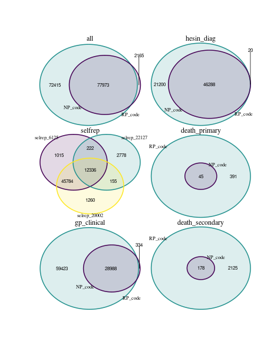

Venn diagram comparison participants - asthma

Download asthma_clinical_codes_RP_venndiagram.pdf

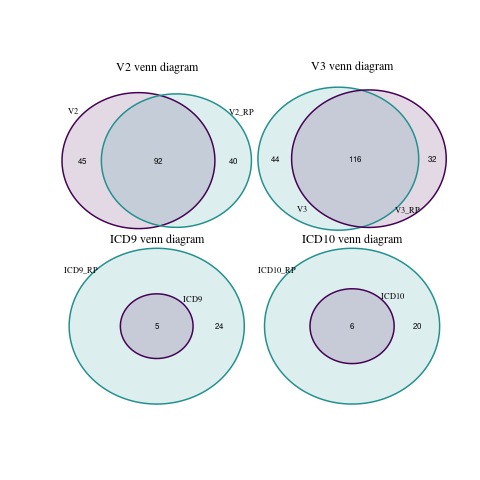

Venn diagram comparison clinical codes - asthma

#### Emphysema/Chronic bronchitis

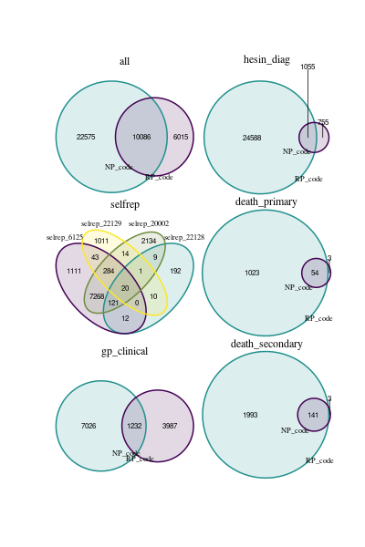

Venn diagram comparison participants - ecb

Download ecb_clinical_codes_RP_venndiagram.pdf

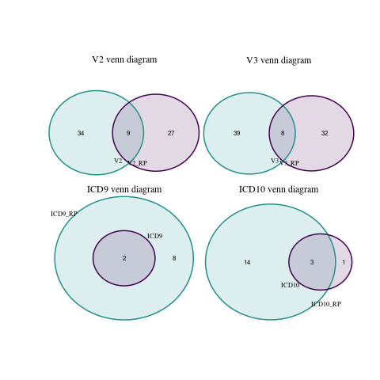

Venn diagram comparison clinical codes - ecb

### Readv2 and ReadCTV3 from data-coding 1834, 1835

#### Observation: missing formatting in Readv2 and ReadCTV3 look-up table brought to a wrong code (00) in my analysis

While checking for data-coding 1834 and 1835, I spotted a wrong code (‘00’) in the file ‘ReadCTV3_Asthma_codes’. The problem was due to the presence of the comma both as separator and as character in some column of the table ‘read_v2_read_ctv3’ in the file ‘all_lkps_maps_v3.xlsx’. Such code is a Readv2 for asthma, and it was retrieved by the searching, but then it was uncorrectly reported as a ReadCTV3 due to mismatching of the column for the presence of the comma. Thus, I rewrote the command leaving the comma just as separator and ‘00’ was not retrieved as readCTV3 code anymore. The total number of individuals with primary clinical code for asthma is now 29322 and the total number of participants with diagnosed asthma is 80138. The number of distinct drug names becomes 49099 (49129 previously) resulting in 48039 distinct drug name (48069 previously) after a first data cleaning (see Medication_list.html). From 15484539 prescriptions and 38866 participants to 15480824 prescriptions and 38822 participants. Genotyped individuals: with asthma diagnosis from 77651 to 77602; 15065507 prescriptions and 37846 participants to 15061792 prescriptions and 37802 participants.

# Conclusion

## Actions for Richard Packer’s clinical codes

The number of participants retrieved by Richard Packer’s codes is higher for both asthma and emphysema/chronic bronchitis. I am not sure this clinical codes retrieve teh actual number of asthma participants in UK Biobank. I will therefore use to define asthma the analysis and clinical codes as I implemented. I will exclude the participants found by Richard Packer’s clinical codes -both asthma and emphysema/chronic bronchitis- from the control in order to be sure that I will take participants free from asthma. I could also run a sensitivity analysis using Richard Packer’s asthma participants as case.